# Tidy Tuesday 2018_04_16

```r
library(tidyverse)
library(here)
library(readxl)
library(skimr)
library(janitor)
```

```r
global_mortality <- read_excel(path = "2018_04_16/data/global_mortality.xlsx")
```

# Initial Observations

```r
str(global_mortality)
```

```
tibble [6,156 x 35] (S3: tbl_df/tbl/data.frame)
 $ country                                 : chr [1:6156] "Afghanistan" "Afghanistan" "Afghanistan" "Afghanistan" ...
 $ country_code                            : chr [1:6156] "AFG" "AFG" "AFG" "AFG" ...
 $ year                                    : num [1:6156] 1990 1991 1992 1993 1994 ...
 $ Cardiovascular diseases (%)             : num [1:6156] 17.6 17.8 18.4 19 19.1 ...
 $ Cancers (%)                             : num [1:6156] 4.03 4.05 4.17 4.27 4.26 ...
 $ Respiratory diseases (%)                : num [1:6156] 2.11 2.13 2.21 2.28 2.31 ...
 $ Diabetes (%)                            : num [1:6156] 3.83 3.82 3.9 3.97 3.97 ...
 $ Dementia (%)                            : num [1:6156] 0.531 0.532 0.54 0.554 0.55 ...
 $ Lower respiratory infections (%)        : num [1:6156] 10.89 10.36 10.1 9.87 9.53 ...
 $ Neonatal deaths (%)                     : num [1:6156] 9.18 8.94 8.84 8.68 8.38 ...
 $ Diarrheal diseases (%)                  : num [1:6156] 2.5 2.57 2.71 3.36 3.08 ...
 $ Road accidents (%)                      : num [1:6156] 3.72 3.73 3.82 3.88 3.86 ...
 $ Liver disease (%)                       : num [1:6156] 0.837 0.846 0.875 0.901 0.905 ...
 $ Tuberculosis (%)                        : num [1:6156] 5.88 5.89 6.03 6.16 6.14 ...
```

[output cut: 21 more lines]

```r
skim(global_mortality)
```

```
-- Data Summary ------------------------
                           Values
Name                       global_mortality
Number of rows             6156
Number of columns          35
_______________________
Column type frequency:
  character                2
  numeric                  33
________________________
Group variables            None

-- Variable type: character ----------------------------------------------------
# A tibble: 2 x 8
  skim_variable n_missing complete_rate   min   max empty n_unique whitespace
```

[output cut: 76 more lines]

## Tidy variable names

To make manipulation easier - currently non-syntactic

```r
global_mortality <- rename_with(global_mortality, function(x){
  str_remove_all(x, "( \\(%\\))|\\(|\\)") %>%
    tolower %>%
    str_replace_all(" |\\/|-", "_")
})

names(global_mortality)
```

```
 [1] "country"                            "country_code"
 [3] "year"                               "cardiovascular_diseases"
 [5] "cancers"                            "respiratory_diseases"
 [7] "diabetes"                           "dementia"
 [9] "lower_respiratory_infections"       "neonatal_deaths"
[11] "diarrheal_diseases"                 "road_accidents"
[13] "liver_disease"                      "tuberculosis"
[15] "kidney_disease"                     "digestive_diseases"
[17] "hiv_aids"                           "suicide"
[19] "malaria"                            "homicide"
[21] "nutritional_deficiencies"           "meningitis"
[23] "protein_energy_malnutrition"        "drowning"
[25] "maternal_deaths"                    "parkinson_disease"
[27] "alcohol_disorders"                  "intestinal_infectious_diseases"
[29] "drug_disorders"                     "hepatitis"
[31] "fire"                               "heat_related_hot_and_cold_exposure"
[33] "natural_disasters"                  "conflict"
[35] "terrorism"
```

## Missing values

### Explicit

#### country_codes

864 country_codes ‘missing’.

Also maximum length is 8 characters - I thought all codes are 3 letters so need to explore what codes >3 characters represent.

```r
# what does country_code N/A represent?
na_country_code <-
  global_mortality[which(is.na(global_mortality$country_code)),] %>%
  pull(country) %>%
  unique
na_country_code
```

```
 [1] "Andean Latin America"         "Australasia"
 [3] "Caribbean"                    "Central Asia"
 [5] "Central Europe"               "Central Latin America"
 [7] "Central Sub-Saharan Africa"   "East Asia"
 [9] "Eastern Europe"               "Eastern Sub-Saharan Africa"
[11] "England"                      "High SDI"
[13] "High-income Asia Pacific"     "High-middle SDI"
[15] "Latin America and Caribbean"  "Low SDI"
[17] "Low-middle SDI"               "Middle SDI"
[19] "North Africa and Middle East" "North America"
[21] "Northern Ireland"             "Oceania"
[23] "Scotland"                     "South Asia"
[25] "Southeast Asia"               "Southern Latin America"
[27] "Southern Sub-Saharan Africa"  "Sub-Saharan Africa"
[29] "Tropical Latin America"       "Wales"
[31] "Western Europe"               "Western Sub-Saharan Africa"
```

```r
# vector created to use when filtering global_mortality dataset
```

These are further groupings of countries that may be useful for further analysis.

```r
# check country codes > 3 characters
global_mortality %>%
  select(starts_with("country")) %>%
  mutate(chars = nchar(country_code)) %>%
  filter(!is.na(country_code) & chars > 3) %>%
  distinct()
```

| country | country_code | chars |
| --- | --- | --- |
| World | OWID_WRL | 8 |

All are 3 letters except “World” with country_code “OWID_WRL”

#### year

```r
unique(global_mortality$year)
```

```
 [1] 1990 1991 1992 1993 1994 1995 1996 1997 1998 1999 2000 2001 2002 2003 2004
[16] 2005 2006 2007 2008 2009 2010 2011 2012 2013 2014 2015 2016
```

27 years - no gaps in data. From 1990 to 2016.

#### terrorism/conflict

1398 observations missing in both categories.

Explore which countries/ years this applies to and whether should be N/A or zero.

```r
terror_NA <- is.na(global_mortality$terrorism)
conflict_NA <- is.na(global_mortality$conflict)

# check if missing data relates to same observations
identical(terror_NA, conflict_NA)
```

```
[1] TRUE
```

```r
global_mortality[terror_NA,] %>%
  select(starts_with("country"), "year", contains(c("conflict", "terrorism"))) %>%
  group_by(year) %>%
  tally()
```

| year | n |
| --- | --- |
| 1990 | 45 |
| 1991 | 45 |
| 1992 | 45 |
| 1993 | 228 |
| 1994 | 45 |
| 1995 | 45 |
| 1996 | 45 |
| 1997 | 45 |
| 1998 | 45 |
| 1999 | 45 |

[output cut: 17 more lines]

```r
NA
```

```r
global_mortality[terror_NA,] %>%
  select(starts_with("country"), "year", contains(c("conflict", "terrorism"))) %>%
  group_by(country) %>%
  tally %>%
  filter (n > 1)
```

| country | n |
| --- | --- |
| American Samoa | 27 |
| Andean Latin America | 27 |
| Australasia | 27 |
| Bermuda | 27 |
| Bosnia and Herzegovina | 27 |
| Cape Verde | 27 |
| Caribbean | 27 |
| Central Europe | 27 |
| Central Latin America | 27 |
| Central Sub-Saharan Africa | 27 |

[output cut: 35 more lines]

```r
global_mortality %>%
  filter(year == 1993) %>%
  select(starts_with("country"), "year", contains(c("conflict", "terrorism"))) %>%
  filter (is.na(conflict))
```

| country | country_code | year | conflict | terrorism |
| --- | --- | --- | --- | --- |
| Afghanistan | AFG | 1993 | NA | NA |
| Albania | ALB | 1993 | NA | NA |
| Algeria | DZA | 1993 | NA | NA |
| American Samoa | ASM | 1993 | NA | NA |
| Andean Latin America | NA | 1993 | NA | NA |
| Andorra | AND | 1993 | NA | NA |
| Angola | AGO | 1993 | NA | NA |
| Antigua and Barbuda | ATG | 1993 | NA | NA |
| Argentina | ARG | 1993 | NA | NA |
| Armenia | ARM | 1993 | NA | NA |

[output cut: 218 more lines]

45 countries where there is no data for any years relating to mortality from conflict or terrorism.

In the year 1993 - all 228 countries had no data for either of these categories. Not evident why this was the case.

### Implicit

#### Is mortality data complete?

Check if the mortality figures for each country and year add up to 100% . Are there deaths where cause not evident or recorded. How does this vary between countries and years.

```r
# subtract % of all causes from 100 for each country and year
global_mortality <-
  global_mortality %>%
  mutate(unspecified = 100 - rowSums(across(cardiovascular_diseases:terrorism),
                                       na.rm = T))
```

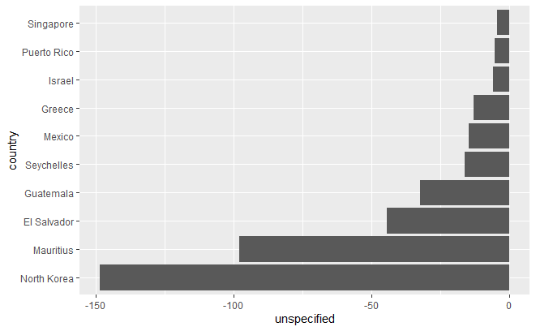

```r
global_mortality %>%
  group_by(country) %>%
  summarise(unspecified = sum(unspecified, na.rm = TRUE)) %>%
  filter(unspecified < 0) %>%
  mutate(country = fct_reorder(country, unspecified)) %>%
  ggplot(aes(y = country, x = unspecified))+
  geom_col()
```

There appear to be some 10 countries where mortality adds up to more than 100%. This will affect the validity of results including these countries. Further exploration of their data is indicated.

```r
NK <- global_mortality %>%
  filter(country == "North Korea" & unspecified < 0)
NK
```

| country | country_code | year | cardiovascular_diseases | cancers | respiratory_diseases | diabetes | dementia | lower_respiratory_infections | neonatal_deaths | diarrheal_diseases | road_accidents | liver_disease | tuberculosis | kidney_disease | digestive_diseases | hiv_aids | suicide | malaria | homicide | nutritional_deficiencies | meningitis | protein_energy_malnutrition | drowning | maternal_deaths | parkinson_disease | alcohol_disorders | intestinal_infectious_diseases | drug_disorders | hepatitis | … |
| --- | --- | --- | --- | --- | --- | --- | --- | --- | --- | --- | --- | --- | --- | --- | --- | --- | --- | --- | --- | --- | --- | --- | --- | --- | --- | --- | --- | --- | --- | --- |
| North Korea | PRK | 1995 | 18.57748 | 13.77523 | 7.802396 | 1.830722 | 1.270280 | 2.501674 | 4.200922 | 1.3400765 | 2.261034 | 1.104131 | 0.9249698 | 0.8246086 | 0.8722992 | 0.03247622 | 1.240662 | 0.002714288 | 0.3255316 | 35.54501 | 0.1275934 | 35.51870 | 0.9725765 | 0.2413673 | 0.07889977 | 0.09361011 | 0.02910798 | 0.2154799 | 0.1193690 | … |
| North Korea | PRK | 1996 | 19.04355 | 13.82990 | 7.922737 | 1.875223 | 1.279248 | 2.573084 | 4.240476 | 1.3944224 | 2.298376 | 1.118449 | 0.9378401 | 0.8414585 | 0.8812207 | 0.03957471 | 1.238007 | 0.002514060 | 0.3269504 | 34.51200 | 0.1289889 | 34.48514 | 0.9739502 | 0.2463376 | 0.07940259 | 0.09450287 | 0.02825683 | 0.2147710 | 0.1208731 | … |
| North Korea | PRK | 1997 | 19.56415 | 13.89411 | 8.052238 | 1.924055 | 1.288448 | 2.623036 | 4.243347 | 1.4264050 | 2.337913 | 1.132151 | 0.9589840 | 0.8608742 | 0.8913150 | 0.04736384 | 1.237690 | 0.002318242 | 0.3270552 | 33.51702 | 0.1292471 | 33.48958 | 0.9879704 | 0.2515822 | 0.07993021 | 0.09545053 | 0.02726512 | 0.2139500 | 0.1222700 | … |
| North Korea | PRK | 1998 | 20.07964 | 13.95344 | 8.160701 | 1.970782 | 1.295180 | 2.659354 | 4.216613 | 1.4071664 | 2.370879 | 1.142182 | 0.9813473 | 0.8788070 | 0.9005215 | 0.05620872 | 1.232034 | 0.002131000 | 0.3258314 | 32.56453 | 0.1290161 | 32.53676 | 1.0299114 | 0.2558721 | 0.08022067 | 0.09623770 | 0.02615873 | 0.2127707 | 0.1234308 | … |
| North Korea | PRK | 1999 | 20.70501 | 14.03532 | 8.183783 | 2.023224 | 1.307284 | 2.677885 | 4.149609 | 1.3409593 | 2.441725 | 1.138847 | 1.0109675 | 0.9033030 | 0.9124753 | 0.06603417 | 1.208612 | 0.001976930 | 0.3178915 | 31.71174 | 0.1280948 | 31.68293 | 1.0149113 | 0.2593808 | 0.08091635 | 0.09733312 | 0.02525791 | 0.2078530 | 0.1227323 | … |
| North Korea | PRK | 2000 | 21.34971 | 14.12599 | 8.243742 | 2.075261 | 1.321001 | 2.675081 | 4.043144 | 1.2369148 | 2.484691 | 1.136022 | 1.0395339 | 0.9278865 | 0.9255075 | 0.07710610 | 1.186788 | 0.001859173 | 0.3098782 | 30.93690 | 0.1269793 | 30.90730 | 1.0101282 | 0.2615104 | 0.08180913 | 0.09824959 | 0.02439847 | 0.2041167 | 0.1219589 | … |
| North Korea | PRK | 2001 | 21.96700 | 14.25442 | 8.298488 | 2.119826 | 1.336759 | 2.636934 | 3.910615 | 1.0971971 | 2.531438 | 1.133775 | 1.0548491 | 0.9504604 | 0.9383750 | 0.08975175 | 1.169666 | 0.001764495 | 0.3027009 | 30.26477 | 0.1262103 | 30.23404 | 1.0088999 | 0.2624386 | 0.08313091 | 0.09908988 | 0.02357253 | 0.2015388 | 0.1211956 | … |
| North Korea | PRK | 2002 | 22.58209 | 14.40681 | 8.375840 | 2.163692 | 1.357167 | 2.578651 | 3.737855 | 0.9481091 | 2.572203 | 1.134082 | 1.0639109 | 0.9731456 | 0.9513579 | 0.10295693 | 1.157922 | 0.001680477 | 0.2962301 | 29.73672 | 0.1245628 | 29.70540 | 1.0040708 | 0.2613291 | 0.08474059 | 0.09985017 | 0.02281729 | 0.2000227 | 0.1205743 | … |

It appears that deaths from ‘nutritional_deficiencies’ and ‘protein-energy_malnutrition’ may be double counted resulting in total mortality >100%. Q: is it valid to remove ‘protein-energy_malnutrition’ as a variable??

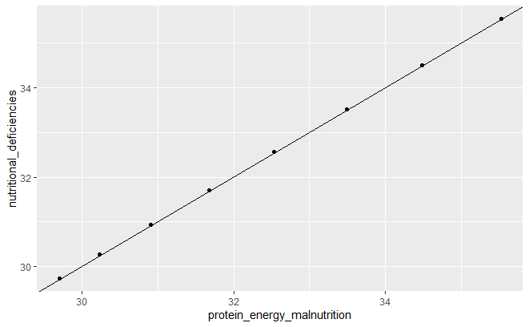

```r
NK %>%
  ggplot(aes(x = protein_energy_malnutrition, y = nutritional_deficiencies))+
  geom_point()+
  geom_abline()
```

Explore across entire data set to see if this pattern is repeated.

#### Exploration of correlation between variables

```r
cor_mortality <- cor(global_mortality[, c("nutritional_deficiencies",
                         "protein_energy_malnutrition",
                         "lower_respiratory_infections", "tuberculosis",
                         "respiratory_diseases", "diarrheal_diseases",
                         "digestive_diseases", "intestinal_infectious_diseases",
                         "heat_related_hot_and_cold_exposure", "fire",
                         "natural_disasters")])
```

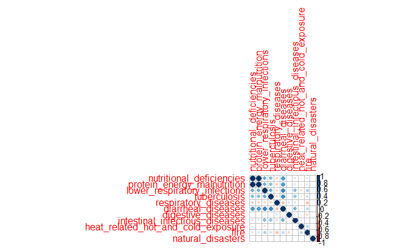

```r
corrplot::corrplot(corr = cor_mortality)
```

Strong correlation across entire dataset between “nutritional_deficiencies” and “protein-energy_malnutrition”. Seems reasonable to remove the more specific “protein-energy_malnutrition” variable on the assumption that these deaths are included under "nutritional_deficiencies

```r
#check that mortality from nutritional_deficiencies is > that from protein_energy_malnutrition across the data set

global_mortality %>%
  filter(protein_energy_malnutrition > nutritional_deficiencies)
```

| country | country_code | year | cardiovascular_diseases | cancers | respiratory_diseases | diabetes | dementia | lower_respiratory_infections | neonatal_deaths | diarrheal_diseases | road_accidents | liver_disease | tuberculosis | kidney_disease | digestive_diseases | hiv_aids | suicide | malaria | homicide | nutritional_deficiencies | meningitis | protein_energy_malnutrition | drowning | maternal_deaths | parkinson_disease | alcohol_disorders | intestinal_infectious_diseases | drug_disorders | hepatitis | … |
| --- | --- | --- | --- | --- | --- | --- | --- | --- | --- | --- | --- | --- | --- | --- | --- | --- | --- | --- | --- | --- | --- | --- | --- | --- | --- | --- | --- | --- | --- | --- |

```r
# zero cases so this is further evidence of 'double counting'

global_mortality$protein_energy_malnutrition <- NULL
```

#### Re-evaluate mortality data completeness

Now repeat previous code to assess completeness of data across rows

```r
global_mortality <-
  global_mortality %>%
  mutate(unspecified = 100 - rowSums(across(cardiovascular_diseases:terrorism),
                                       na.rm = T))
```

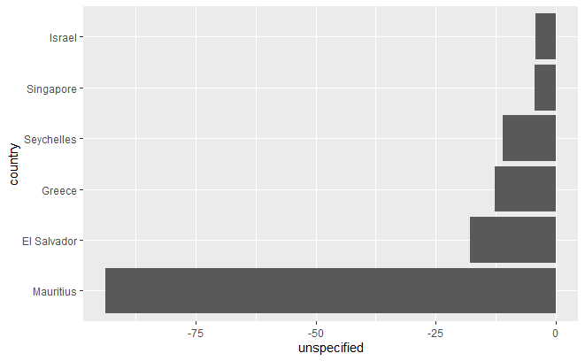

```r
global_mortality %>%
  group_by(country) %>%
  summarise(unspecified = sum(unspecified, na.rm = TRUE)) %>%
  filter(unspecified < 0) %>%
  mutate(country = fct_reorder(country, unspecified)) %>%
  ggplot(aes(y = country, x = unspecified))+
  geom_col()
```

Mauritius is still an outlier.

```r
global_mortality %>%
  filter(country == "Mauritius" & unspecified < 0)
```

| country | country_code | year | cardiovascular_diseases | cancers | respiratory_diseases | diabetes | dementia | lower_respiratory_infections | neonatal_deaths | diarrheal_diseases | road_accidents | liver_disease | tuberculosis | kidney_disease | digestive_diseases | hiv_aids | suicide | malaria | homicide | nutritional_deficiencies | meningitis | drowning | maternal_deaths | parkinson_disease | alcohol_disorders | intestinal_infectious_diseases | drug_disorders | hepatitis | fire | … |
| --- | --- | --- | --- | --- | --- | --- | --- | --- | --- | --- | --- | --- | --- | --- | --- | --- | --- | --- | --- | --- | --- | --- | --- | --- | --- | --- | --- | --- | --- | --- |
| Mauritius | MUS | 1990 | 45.54187 | 9.342354 | 6.371196 | 9.805059 | 2.187382 | 4.320299 | 4.3895920 | 0.9665808 | 1.946936 | 3.375720 | 0.3699317 | 4.658237 | 1.619947 | 0.19035158 | 2.030440 | 0.001572696 | 0.3835522 | 0.35290852 | 0.29168727 | 0.7470346 | 0.23951093 | 0.1516288 | 0.9220618 | 0.05783261 | 0.02867012 | 0.05660044 | 0.9229960 | … |
| Mauritius | MUS | 1991 | 45.54742 | 9.449183 | 6.131462 | 10.040382 | 2.254275 | 4.314251 | 4.3155777 | 0.8261339 | 2.085441 | 3.563981 | 0.3517207 | 4.778669 | 1.541938 | 0.07081946 | 2.046419 | 0.001584002 | 0.3889327 | 0.27869167 | 0.30102781 | 0.7310355 | 0.24925544 | 0.1570696 | 0.9533268 | 0.05567867 | 0.02253383 | 0.05005855 | 0.8735591 | … |
| Mauritius | MUS | 1992 | 45.68051 | 9.670966 | 5.975577 | 10.056306 | 2.312998 | 4.290423 | 4.2234611 | 0.7483918 | 2.118658 | 3.754459 | 0.3242990 | 4.864219 | 1.457156 | 0.06243726 | 2.060007 | 0.001608276 | 0.3853790 | 0.21959655 | 0.29407385 | 0.7244204 | 0.21527005 | 0.1618269 | 0.9316862 | 0.05351566 | 0.02140594 | 0.03668554 | 0.8340352 | … |
| Mauritius | MUS | 1993 | 46.21983 | 9.706207 | 5.743643 | 9.996415 | 2.378162 | 4.258825 | 4.0246920 | 0.6468045 | 2.190906 | 3.859201 | 0.2988796 | 4.977070 | 1.423492 | 0.08949869 | 2.027732 | 0.001627247 | 0.3737874 | 0.18066496 | 0.29490263 | 0.7125393 | 0.19364615 | 0.1671123 | 0.9438726 | 0.05168747 | 0.02128154 | 0.03620381 | 0.8088089 | … |
| Mauritius | MUS | 1994 | 46.49789 | 9.893785 | 5.630223 | 9.914800 | 2.458476 | 4.190268 | 3.7846969 | 0.5489015 | 2.238621 | 3.999309 | 0.2725806 | 5.058549 | 1.383449 | 0.07889864 | 2.004851 | 0.001638876 | 0.3713953 | 0.13860649 | 0.27837638 | 0.7510899 | 0.22433150 | 0.1736739 | 0.9195920 | 0.04975172 | 0.02336557 | 0.02926557 | 0.7783905 | … |
| Mauritius | MUS | 1995 | 46.76088 | 9.863019 | 5.427751 | 10.112540 | 2.539837 | 4.088378 | 3.6374746 | 0.5023447 | 2.279428 | 4.122571 | 0.2431725 | 5.278265 | 1.364445 | 0.06822937 | 2.028083 | 0.001648245 | 0.3682432 | 0.12157156 | 0.27455637 | 0.7783807 | 0.20637088 | 0.1805326 | 0.8926535 | 0.04778043 | 0.02614196 | 0.02263707 | 0.7524702 | … |
| Mauritius | MUS | 1996 | 47.14702 | 9.840743 | 5.312302 | 10.430509 | 2.619809 | 3.963118 | 3.4947995 | 0.4157264 | 2.183045 | 4.192592 | 0.2207693 | 5.493943 | 1.315980 | 0.08341043 | 2.021692 | 0.001666600 | 0.3767154 | 0.09717395 | 0.25727247 | 0.7905884 | 0.16653924 | 0.1880575 | 0.8458929 | 0.04562536 | 0.02397499 | 0.01505448 | 0.7205604 | … |
| Mauritius | MUS | 1997 | 47.87113 | 9.832394 | 5.302766 | 10.494556 | 2.709766 | 3.830581 | 3.2506363 | 0.3534846 | 2.154047 | 4.177724 | 0.2240737 | 5.445639 | 1.311074 | 0.05166136 | 1.936747 | 0.001693824 | 0.3681747 | 0.07500203 | 0.23985135 | 0.7483284 | 0.15895070 | 0.1964560 | 0.7770279 | 0.04419928 | 0.02209835 | 0.01498589 | 0.6902911 | … |
| Mauritius | MUS | 1998 | 48.04682 | 10.113967 | 5.353782 | 10.530637 | 2.835291 | 3.645718 | 3.0801309 | 0.2921127 | 2.142797 | 4.127279 | 0.1907910 | 5.207237 | 1.342679 | 0.08656407 | 1.944567 | 0.001695430 | 0.3629737 | 0.08836766 | 0.22954325 | 0.6828440 | 0.13617201 | 0.2069837 | 0.6554905 | 0.04189150 | 0.02334893 | 0.01056476 | 0.6117380 | … |
| Mauritius | MUS | 1999 | 47.80741 | 10.368340 | 5.439818 | 10.893695 | 2.959229 | 3.484261 | 2.8800363 | 0.2699166 | 2.157737 | 4.038199 | 0.1861906 | 5.127417 | 1.376135 | 0.05565770 | 1.895439 | 0.001694058 | 0.3627349 | 0.09488125 | 0.22074528 | 0.6242697 | 0.13315587 | 0.2181475 | 0.5986638 | 0.04006103 | 0.02987597 | 0.01049876 | 0.5858875 | … |

[output cut: 17 more lines]

```r
NA
```

Most years report total mortality >100% - no obvious pattern. Explore further with correlation matrix

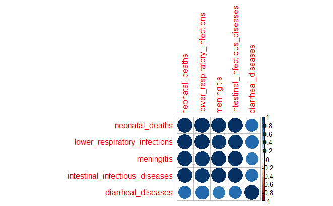

```r
global_mortality %>%
  filter(country == "Mauritius") %>%
  select(contains(c("neonatal_deaths","lower_respiratory_infections", "meningitis", "intestinal_infectious_diseases", "diarrheal_diseases"))) %>%
  cor() %>%
  corrplot::corrplot()
```

May be neonatal deaths resulting in double counting for cause of death i.e. infection vs. type of death ie. neonatal.

Explore across entire dataset to explore if a wider issue

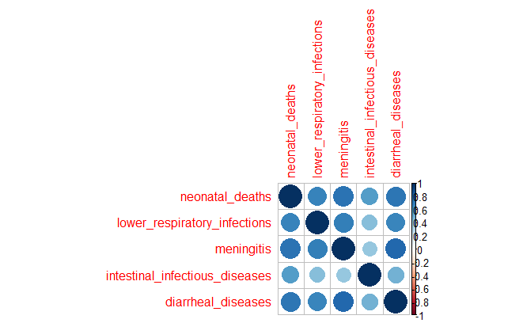

```r
global_mortality %>%
  select(contains(c("neonatal_deaths","lower_respiratory_infections", "meningitis", "intestinal_infectious_diseases", "diarrheal_diseases"))) %>%
  cor() %>%
  corrplot::corrplot()
```

Some correlation exists but not as strong as for Mauritius. Not enough evidence to remove any data.

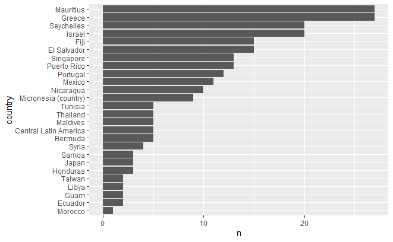

```r
global_mortality[global_mortality$unspecified < 0, ] %>%
  group_by(country) %>%
  tally() %>%
  mutate(country = fct_reorder(country, n)) %>%
    ggplot(aes(x = n, y = country)) +
    geom_col()
```

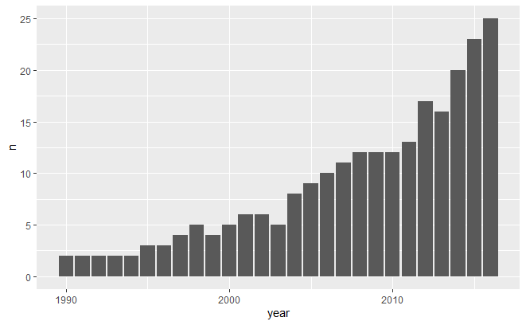

```r
global_mortality[global_mortality$unspecified < 0, ] %>%
  group_by(year) %>%
  tally()  %>%
  ggplot(aes(y = n, x = year))+
  geom_bar(stat = "identity")
```

#### Discussion

There appears to be considerable variation between different countries as to how causes of death are recorded. This seems to result in deaths being attributed to more than one cause in a significant number of observations. The number of observations where combined mortality is >100% has increased over time. This may be a result of how data is collected.

## Saving data

### Create longer version

```r
global_mortality_long <-
  global_mortality %>%
    pivot_longer(data = .,
                 cols = -c(1:3),
                 names_to = "causes",
                 values_to = "percent_total")


# global_mortality %>% select(-c(1:3))
```

#### Save objects as binary files

```r
save(... = global_mortality_long,
     file = "2018_04_16/data/global_mortality_long.rda")

save(... = global_mortality,
     file = "2018_04_16/data/global_mortality.rda")
```

#### Save master file as csv

```r
write_csv(global_mortality, "2018_04_16/data/global_mortality.csv")
```

#### Subset master file and save

```r
all_countries_mortality <-
  global_mortality %>%
  filter(!country %in% na_country_code)

save(... = all_countries_mortality, file = "2018_04_16/data/all_countries_mortality.rda")

all_countries_mortality_long <-
  global_mortality_long %>%
  filter(!country %in% na_country_code)

save(... = all_countries_mortality_long, file = "2018_04_16/data/all_countries_mortality_long.rda")
```

```r
grouped_mortality_long <-
  global_mortality_long %>%
  filter(country %in% na_country_code & !country %in% c("England", "Wales",
                                 "Scotland", "Northern Ireland"))

save(... = grouped_mortality_long, file = "2018_04_16/data/grouped_mortality_long.rda")

grouped_mortality <-
  global_mortality %>%
  filter(country %in% na_country_code & !country %in% c("England", "Wales",
                                 "Scotland", "Northern Ireland"))

save(... = grouped_mortality, file = "2018_04_16/data/grouped_mortality.rda")
```

```r
united_kingdom <-
  global_mortality_long %>%
  filter(country %in% c("United Kingdom", "England", "Scotland", "Wales",
                        "Northern Ireland", "Western Europe", "World"))

save(... = united_kingdom, file = "2018_04_16/data/united_kingdom_mortality.rda")
```

## Tidy up environment

```r
rm(cor_mortality, NK, conflict_NA, terror_NA, na_country_code)
```